# External validation

Erik Bulow

2019-11-13

# Start

Install and attatch some useful packages

```r
pkgs <- c("tidyverse", "doParallel", "pROC", "rms", "givitiR")

# Install
pkgsinst <- setdiff(pkgs, rownames(installed.packages()))
if (length(pkgsinst)) install.packages(pkgsinst)

# Attatch
purrr::walk(pkgs, ~suppressPackageStartupMessages(library(., character.only = TRUE)))
```

Load the exported model to validate (the R object previsously sent, probably with another path).

```r
# Load the exported model object
load("../cache/fit_export.RData")
```

Set random seed for reproducability:

```r
set.seed(123)
```

# Prepare data

## Inclusion/exlusion

Those were the inclusions/exklusions from Sweden. It might not be necessary to filter out on BMI, hospital and education however. Those variables are not used in the model.

Additional filter to ages 35-99 years to match the Swedish cohort.

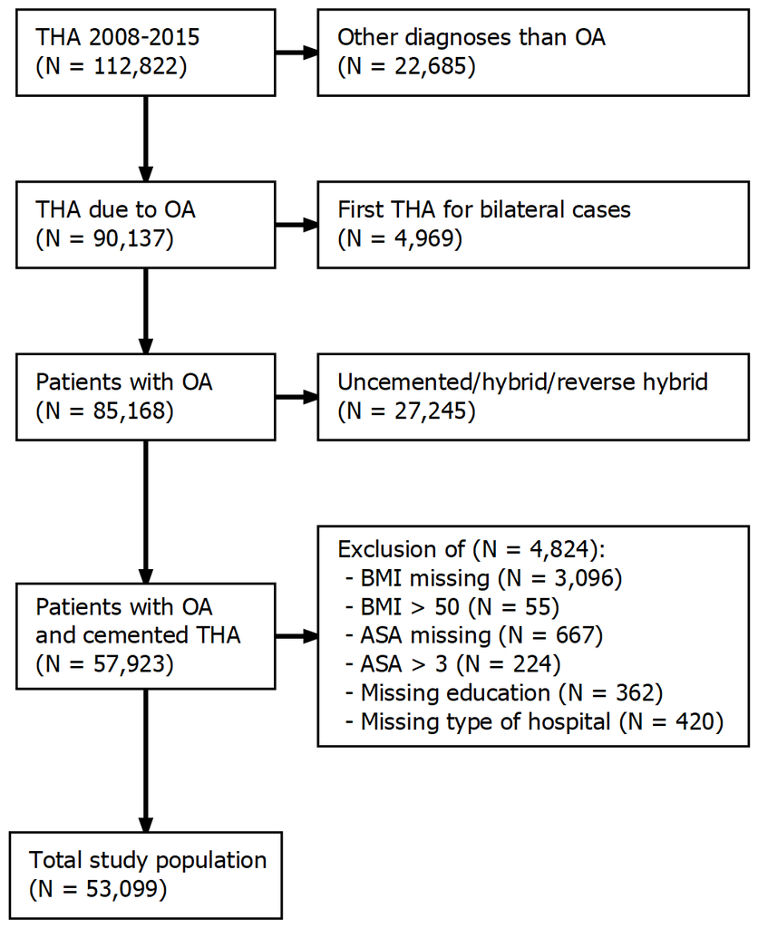

```r
knitr::include_graphics("../graphs/flowchart.png")
```

# Variables

## Outcome

The outcome variable is boolean (or numeric) indicating wether the patient died of any cause within 90 days after THA (`TRUE`/1) or not (`FALSE`/0). We did not have any censoring in Sweden. I guess we can simply drop cases where status is unknown?

## Predictors

The data to evaluate should look like this:

```r
head(fit_export$data)
```

| c_cancer | c_cns_disease | c_kidney_disease | P_ASA | P_Age | c_obesity | P_Gender |
| --- | --- | --- | --- | --- | --- | --- |
| TRUE | FALSE | FALSE | 2 | 79 | FALSE | Kvinna |
| FALSE | FALSE | FALSE | 2 | 80 | FALSE | Man |
| FALSE | FALSE | TRUE | 3 | 86 | FALSE | Kvinna |
| FALSE | FALSE | FALSE | 2 | 59 | FALSE | Man |
| FALSE | FALSE | FALSE | 1 | 74 | FALSE | Man |
| FALSE | FALSE | FALSE | 2 | 76 | FALSE | Man |

## Baseline variables

- **P_Gender**: Kvinna/Man = Female/Male
- **P_ASA**: level 1-3
- **P_Age**: 35 - 99

## Comorbidities

Comorbidities are identified by Elixhauser and Charlson comorbidity during one year before surgery. This is done by ICD-10 codes in Sweden but other versions exist. If ICD-10-codes are used those might be identified by regular expressions in the table below. Those are based on codes like “C123”. Hence no puntctuation (not “C12.3”). The regular expressions might be modified to allow possible other patterns. Regular expressoins below are just combined from differnet groups (separated by “|”). They could be rewritten for clarity. If you don’t see any regular expressions, click the small arrow in the upper right corner of the table. The `grepl` function (base R) can be used to identify ICD-10-codes based on the regular expressions.

[output not shown]

## Example data

Let’s assume we now have some data (I will use the Swedish data just as an example).

```r
y <- fit_export$y
X <- fit_export$data
```

# Validation of model as is

```r
# Tibble with observed and predicted outcome
obspred <-
  tibble(
    obs  = y,
    pred = predict(fit_export, X, type = "response")
  )

# ROC curve
ROC <- pROC::roc(obspred, "obs", "pred", direction = "<")

# Estimate CI for AUC based on bootstrapping
# Use parallel processing to speed up the process
doParallel::registerDoParallel()
AUCci <-
  pROC::ci.auc(
    ROC,
    method          = "bootstrap",
    boot.stratified = FALSE,
    parallel        = TRUE
  )

# Check calibration. Note that devel should actually be "internal" for this example but I use
# "external", since that's what you will use for the UK data.
calibration <-
  givitiR::givitiCalibrationBelt(
    obspred$obs,
    obspred$pred,
    devel = "external"
  )
```

## Results

For this example we had AUC:

```r
AUCci
```

```
## 95% CI: 0.749-0.813 (2000 non-stratified bootstrap replicates)
```

```r
plot(ROC)
```

[output not shown]

A calibration belt plot might be illustrated as:

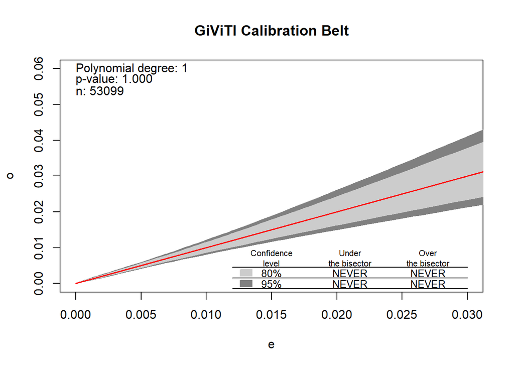

```
## $m
## [1] 1
##
## $p.value
## [1] 1
```

```r
plot(calibration, xlim = c(0, 0.03), ylim = c(0, 0.06))
```

# Re-calibrated intercept

Method 2 from table 1 in Steyerberg 2004.

```r
Z <- predict(fit_export, X, type = "response")

# Refit the intercept using Z = a + Xb from above as offset
fit2 <- glm(y ~ 1, offset = Z)

# Same calibration and validation as above
obspred2     <- tibble(obs  = y, pred = predict(fit2, type = "response"))
ROC2         <- pROC::roc(obspred2, "obs", "pred", direction = "<")
AUCci2       <- pROC::ci.auc(ROC2, method = "bootstrap", boot.stratified = FALSE, parallel = TRUE)
calibration2 <- givitiR::givitiCalibrationBelt(obspred2$obs, obspred2$pred, devel = "external")
```

## Results

```r
AUCci2
```

```
## 95% CI: 0.748-0.814 (2000 non-stratified bootstrap replicates)
```

```r
plot(ROC2)
```

[output not shown]

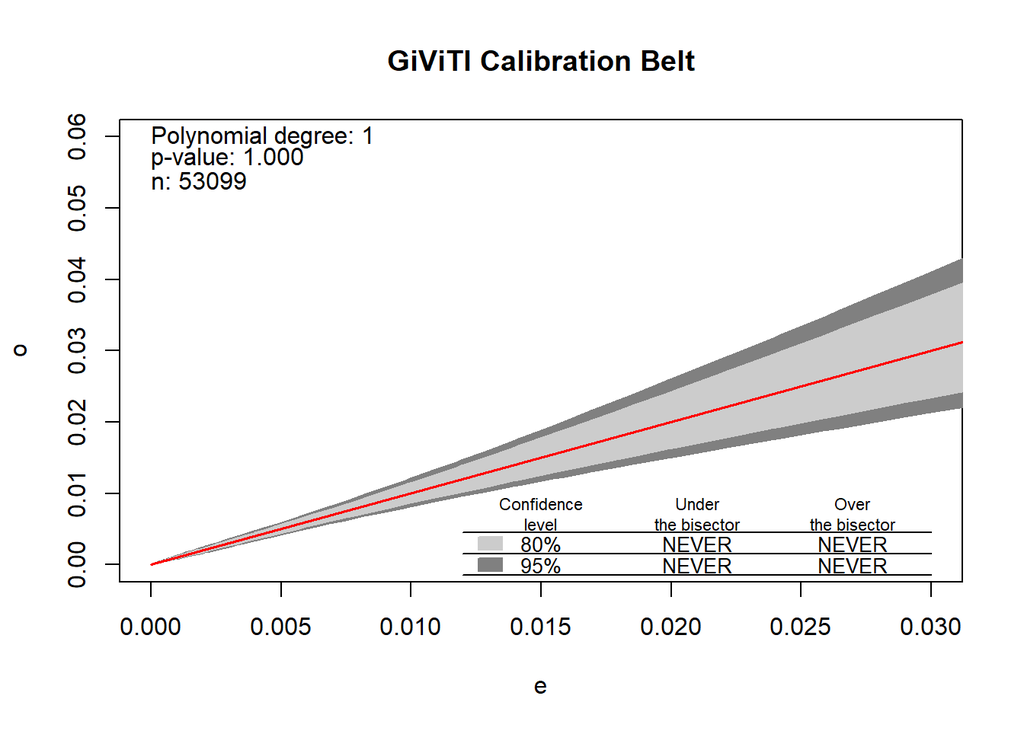

```
## $m
## [1] 1
##
## $p.value
## [1] 1
```

```r
plot(calibration2, xlim = c(0, 0.03), ylim = c(0, 0.06))
```

# Re-calibration of intercenpt and calibration slope

Method 3 from table 1 in Steyerberg 2004.

```r
fit3         <- glm(y ~ 1 + Z)
obspred3     <- tibble(obs  = y, pred = predict(fit3, type = "response"))
ROC3         <- pROC::roc(obspred3, "obs", "pred", direction = "<")
AUCci3       <- pROC::ci.auc(ROC3, method = "bootstrap", boot.stratified = FALSE, parallel = TRUE)
calibration3 <- givitiR::givitiCalibrationBelt(obspred3$obs, obspred3$pred, devel = "external")
```

## Results

```r
AUCci3
```

```
## 95% CI: 0.7483-0.8139 (2000 non-stratified bootstrap replicates)
```

```r
plot(ROC3)
```

[output not shown]

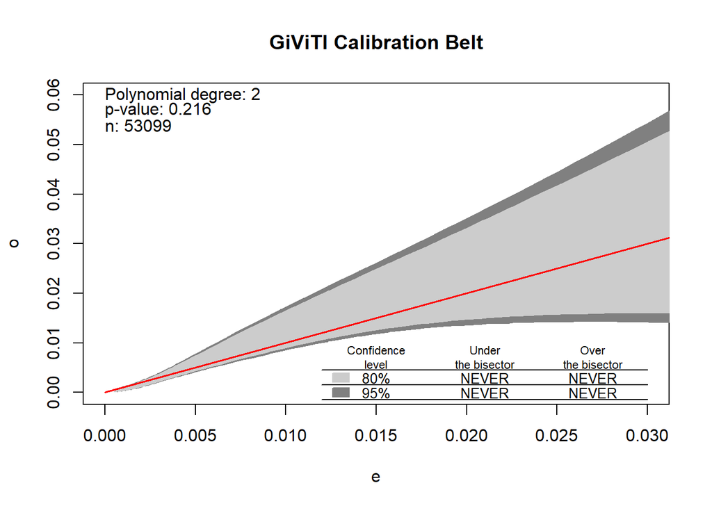

```
## $m
## [1] 2
##
## $p.value
## [1] 0.215909
```

```r
plot(calibration3, xlim = c(0, 0.03), ylim = c(0, 0.06))
```

# Export data to Sweden

## ROC

If it would be OK to export coordinates for ROC-plots I would recommend this code to extract only the minimal data needed:

```r
roc_plot_coords <-
  data.frame(
    specificities = ROC$specificities,
    sensitivities = ROC$sensitivities
  )

roc3_plot_coords <-
  data.frame(
    specificities = ROC3$specificities,
    sensitivities = ROC3$sensitivities
  )
```

## AUC with CI

The text output from `AUCci` and `AUCci3` should be enough. Hence, the same character string that gets printed above (but now stored in an object).

```r
AUCci_print  <- capture.output(AUCci)
AUCci3_print <- capture.output(AUCci3)
```

## Export objects

Save objects above to file `export.RData` (in the current working directory).

```r
save(
  roc_plot_coords,
  roc3_plot_coords,
  AUCci_print,
  AUCci3_print,
  file = "export.RData"
)
```

## Calibration plots

### Help function

This is a simple help function to make a clean calibration belt plot and save it as TIFF (in the curent working directory):

```r
makeplot <- function(x, file_name = deparse(substitute(x))) {
  tiff(
    paste0(file_name, ".tiff"),
    1024, 1024, pointsize = 36,
    compression = "lzw"
  )

  tcks <- seq(.0, .1, .01)

  plot(
    x,
    xlim             = c(0, .06),
    ylim             = c(0, .08),
    xlab             = "Predicted probabilities [%]",
    ylab             = "Observed  probabilities [%]",
    main             = NULL,
    table            = FALSE,
    polynomialString = FALSE,
    pvalueString     = FALSE,
    nString          = FALSE,
    mar              = c(5, 4, 0, 0) + 0.1,
    xaxt             = "n",
    yaxt             = "n"
  )
  abline(v = .03, lty = "dashed", col = "darkgreen", lwd = 3)
  axis(1, at = tcks, lab = sprintf("%.0f", tcks * 100), las = TRUE)
  axis(2, at = tcks, lab = sprintf("%.0f", tcks * 100), las = TRUE)

  dev.off()
}
```

### Make and save figures

```r
makeplot(calibration)
```

```r
makeplot(calibration3)
```

## ROC plots

If it not possible to export data for ROC-plot, here is some code to make a figure and save it as TIFF (in the current working directory) instead:

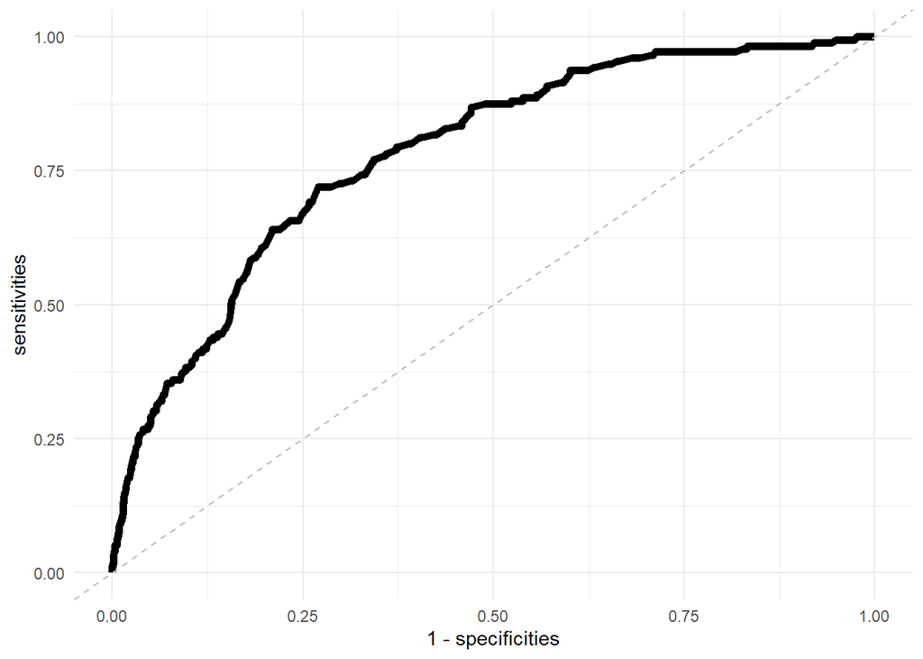

```r
roc_plot_coords %>%
  ggplot(aes(1 - specificities, sensitivities)) +
  geom_path(size = 2) +
  geom_abline(intercept = 0, slope = 1, color = "grey", linetype = 2) +
  theme_minimal() +
  theme(
    legend.position = c(1, 0),
    legend.justification = c(1, 0),
    legend.title = element_blank()
  )
```

```r
ggsave(
  "roc.tiff",
  height = 10,
  width = 10,
  unit = "cm",
  dpi = 900,
  compression = "lzw"
)
```